# Assignment 8

Marko Konte

Anomaly Detection

### Initial reading in of packages

Here we will inport numpy and pandas into our in memory library in order to use it at a later time.

```python
import numpy as np
import pandas as pd
import os
from collections import Counter
import random
from pyod.models.combination import aom, moa, average, maximization
from pyod.utils.utility import standardizer
from pyod.utils.data import generate_data
from pyod.utils.data import evaluate_print
```

```python
## Reading of the key dataset that will be analyzed
df = pd.read_csv("C:\\Users\\marko\\OneDrive\\Documents\\Columbia\\Anomaly Detection - Summer 2019\\inpatientCharges.csv")
df.head()
```

|  | DRG Definition | Provider Id | Provider Name | Provider Street Address | Provider City | Provider State | Provider Zip Code | Hospital Referral Region Description | Total Discharges | Average Covered Charges | Average Total Payments | Average Medicare Payments |
| --- | --- | --- | --- | --- | --- | --- | --- | --- | --- | --- | --- | --- |
| 0 | 039 - EXTRACRANIAL PROCEDURES W/O CC/MCC | 10001 | SOUTHEAST ALABAMA MEDICAL CENTER | 1108 ROSS CLARK CIRCLE | DOTHAN | AL | 36301 | AL - Dothan | 91 | $32963.07 | $5777.24 | $4763.73 |
| 1 | 039 - EXTRACRANIAL PROCEDURES W/O CC/MCC | 10005 | MARSHALL MEDICAL CENTER SOUTH | 2505 U S HIGHWAY 431 NORTH | BOAZ | AL | 35957 | AL - Birmingham | 14 | $15131.85 | $5787.57 | $4976.71 |
| 2 | 039 - EXTRACRANIAL PROCEDURES W/O CC/MCC | 10006 | ELIZA COFFEE MEMORIAL HOSPITAL | 205 MARENGO STREET | FLORENCE | AL | 35631 | AL - Birmingham | 24 | $37560.37 | $5434.95 | $4453.79 |
| 3 | 039 - EXTRACRANIAL PROCEDURES W/O CC/MCC | 10011 | ST VINCENT'S EAST | 50 MEDICAL PARK EAST DRIVE | BIRMINGHAM | AL | 35235 | AL - Birmingham | 25 | $13998.28 | $5417.56 | $4129.16 |
| 4 | 039 - EXTRACRANIAL PROCEDURES W/O CC/MCC | 10016 | SHELBY BAPTIST MEDICAL CENTER | 1000 FIRST STREET NORTH | ALABASTER | AL | 35007 | AL - Birmingham | 18 | $31633.27 | $5658.33 | $4851.44 |

```python
##Changing column names
df.columns = ['DRG_Definition', 'Provider_Id', 'Provider_Name', 'Provider_Street_Address',
              'Provider_City', 'Provider_State', 'Provider_Zip_Code', 'Hospital_Referral_Region_Description',
             'Total_Discharges', 'Average_Covered_Charges', 'Average_Total_Payments', 'Average_Medicare_Payments']
```

```python
df.shape
```

```
(163065, 12)
```

```python
from pyod.models.knn import KNN
from pyod.utils.data import generate_data
from pyod.utils.data import evaluate_print
from pyod.utils.example import visualize
```

```python
#Showing the head of the dataset
df.head()
```

[output not shown]

```python
##Making cost based variables into numeric
#Reassign $ values to integers
df[df.columns[9:]] = df[df.columns[9:]].apply(lambda x: x.str.replace('$','')).apply(lambda x: x.str.replace(',','')).astype(np.float)
```

```python
#Visualizing newly transformed variables as numeric
df.describe()

#Seeing the elements that are in the main dataset
df.shape
```

```
(163065, 12)
```

#### Next we will run the EDA in order to group the data into the set of variables to be used in models

In order to achieve the same features as was done in the RMarkdown files, we will first utilize the GroupBy feature of from pandas. We will then use the corresponding variables to create the final model of features which will be used.

1. Summarizing all cost based variables. We will take the key cost data points rely on the describe function in python to provide us with the count, mean, quartiles, and standard deviation of prices each individual cost based variable. One result in Python that was different was the ability to find the standard deviation of the variance in pricing. This is not of major concern as the data points will be scaled later in the document.

```python
# Using Describe function to input the key metrix of the cost based variables

##Putting together the initial sum variable for the dataset
df_sum = df.groupby(['DRG_Definition','Provider_State', 'Provider_Name'],)[
                   'Total_Discharges', 'Average_Covered_Charges',
                    'Average_Total_Payments', 'Average_Medicare_Payments'].describe().reset_index()
```

```python
df_sum.describe()
```

[output not shown]

8 rows × 32 columns

```python
#Changing the names of the columns for the df_sum feature set
df_sum.columns = ['DRG_Definition','Provider_State', 'Provider_Name','TD_count', 'TD_mean', 'TD_std', 'TD_min', 'TD_25', 'TD_50',
                  'TD_75', 'TD_max','ACC_count',
                   'ACC_mean', 'ACC_std', 'ACC_min', 'ACC_25', 'ACC_50', 'ACC_75', 'ACC_max', 'ATP_count', 'ATP_mean',
                   'ATP_std', 'ATP_min', 'ATP_25', 'ATP_50', 'ATP_75', 'ATP_max','AMP_count', 'AMP_mean', 'AMP_std',
                   'AMP_min', 'AMP_25', 'AMP_50', 'AMP_75', 'AMP_max']
df_sum.head()
```

|  | DRG_Definition | Provider_State | Provider_Name | TD_count | TD_mean | TD_std | TD_min | TD_25 | TD_50 | TD_75 | ... | ATP_75 | ATP_max | AMP_count | AMP_mean | AMP_std | AMP_min | AMP_25 | AMP_50 | AMP_75 | AMP_max |
| --- | --- | --- | --- | --- | --- | --- | --- | --- | --- | --- | --- | --- | --- | --- | --- | --- | --- | --- | --- | --- | --- |
| 0 | 039 - EXTRACRANIAL PROCEDURES W/O CC/MCC | AK | ALASKA REGIONAL HOSPITAL | 1.0 | 23.0 | NaN | 23.0 | 23.0 | 23.0 | 23.0 | ... | 8401.95 | 8401.95 | 1.0 | 6413.78 | NaN | 6413.78 | 6413.78 | 6413.78 | 6413.78 | 6413.78 |
| 1 | 039 - EXTRACRANIAL PROCEDURES W/O CC/MCC | AL | BAPTIST MEDICAL CENTER SOUTH | 1.0 | 67.0 | NaN | 67.0 | 67.0 | 67.0 | 67.0 | ... | 6653.80 | 6653.80 | 1.0 | 5374.14 | NaN | 5374.14 | 5374.14 | 5374.14 | 5374.14 | 5374.14 |
| 2 | 039 - EXTRACRANIAL PROCEDURES W/O CC/MCC | AL | BAPTIST MEDICAL CENTER-PRINCETON | 1.0 | 33.0 | NaN | 33.0 | 33.0 | 33.0 | 33.0 | ... | 5996.00 | 5996.00 | 1.0 | 4962.45 | NaN | 4962.45 | 4962.45 | 4962.45 | 4962.45 | 4962.45 |
| 3 | 039 - EXTRACRANIAL PROCEDURES W/O CC/MCC | AL | BROOKWOOD MEDICAL CENTER | 1.0 | 19.0 | NaN | 19.0 | 19.0 | 19.0 | 19.0 | ... | 4987.26 | 4987.26 | 1.0 | 3944.42 | NaN | 3944.42 | 3944.42 | 3944.42 | 3944.42 | 3944.42 |
| 4 | 039 - EXTRACRANIAL PROCEDURES W/O CC/MCC | AL | D C H REGIONAL MEDICAL CENTER | 1.0 | 31.0 | NaN | 31.0 | 31.0 | 31.0 | 31.0 | ... | 6192.54 | 6192.54 | 1.0 | 5179.38 | NaN | 5179.38 | 5179.38 | 5179.38 | 5179.38 | 5179.38 |

5 rows × 35 columns

#### 2nd grouping of variables

1. Taking the differences from key variables. We will rely on total payments as a baseline and calculate the difference from medicare payments and covered charges. In addition, we will calculate the difference between covered charges and mediare per procedure and state.

```python
###### 2nd Set of features
######Adding difference based variables
df_diff = df[['DRG_Definition', 'Provider_Name', 'Provider_State','Total_Discharges',
                         'Average_Covered_Charges',
                    'Average_Total_Payments', 'Average_Medicare_Payments']]

df_diff['TotPayment_Medicare_Difference'] = df.groupby(['DRG_Definition','Provider_State', 'Provider_Name'],
  group_keys=False).apply(lambda d: d.Average_Total_Payments - d.Average_Medicare_Payments.sum())

df_diff['Covered_Medicare_Difference'] = df.groupby(['DRG_Definition','Provider_State', 'Provider_Name'],
  group_keys=False).apply(lambda d: d.Average_Covered_Charges - d.Average_Medicare_Payments.sum())

df_diff['TotPayments_Covered_Difference'] = df.groupby(['DRG_Definition','Provider_State', 'Provider_Name'],
  group_keys=False).apply(lambda d: d.Average_Total_Payments - d.Average_Covered_Charges.sum())

df_diff.head()
```

[output not shown]

|  | DRG_Definition | Provider_Name | Provider_State | Total_Discharges | Average_Covered_Charges | Average_Total_Payments | Average_Medicare_Payments | TotPayment_Medicare_Difference | Covered_Medicare_Difference | TotPayments_Covered_Difference |
| --- | --- | --- | --- | --- | --- | --- | --- | --- | --- | --- |
| 0 | 039 - EXTRACRANIAL PROCEDURES W/O CC/MCC | SOUTHEAST ALABAMA MEDICAL CENTER | AL | 91 | 32963.07 | 5777.24 | 4763.73 | 1013.51 | 28199.34 | -27185.83 |
| 1 | 039 - EXTRACRANIAL PROCEDURES W/O CC/MCC | MARSHALL MEDICAL CENTER SOUTH | AL | 14 | 15131.85 | 5787.57 | 4976.71 | 810.86 | 10155.14 | -9344.28 |
| 2 | 039 - EXTRACRANIAL PROCEDURES W/O CC/MCC | ELIZA COFFEE MEMORIAL HOSPITAL | AL | 24 | 37560.37 | 5434.95 | 4453.79 | 981.16 | 33106.58 | -32125.42 |
| 3 | 039 - EXTRACRANIAL PROCEDURES W/O CC/MCC | ST VINCENT'S EAST | AL | 25 | 13998.28 | 5417.56 | 4129.16 | 1288.40 | 9869.12 | -8580.72 |
| 4 | 039 - EXTRACRANIAL PROCEDURES W/O CC/MCC | SHELBY BAPTIST MEDICAL CENTER | AL | 18 | 31633.27 | 5658.33 | 4851.44 | 806.89 | 26781.83 | -25974.94 |

#### 3rd set of variables

1. Making key ratios from the cost based variables and total discharge. We will look at the ratio between covered charges and medicare to total payments. In addition, we identify the total payments per discharge, medicare payments per discharge, and covered payments per discharge.

In regards to the features created for the 2nd and 3rd grouping (Difference and Ratio based), it is unclear if the approach that was done is the best way using pandas. The approach relied on the .apply function to create a newly calculated variable (similar to 'Mutate' in R). This often times created a warning titled SettingWithCopyWarning. We will need to analyze this in more detail to see what the best approach will be to mutate new models using python.

```python
##Adding 3rd set of features- ratio based variables

df_ratio = df[['DRG_Definition', 'Provider_Name', 'Provider_State','Total_Discharges',
                         'Average_Covered_Charges',
                    'Average_Total_Payments', 'Average_Medicare_Payments']]

df_ratio['Medicare_Percentage'] = df.groupby(['DRG_Definition','Provider_State', 'Provider_Name'],
  group_keys=False).apply(lambda g: g.Average_Medicare_Payments/g.Average_Total_Payments.sum())

df_ratio['Covered_Percentage'] = df_ratio.groupby(['DRG_Definition','Provider_State', 'Provider_Name'],
  group_keys=False).apply(lambda g: g.Average_Covered_Charges/g.Average_Total_Payments.sum())

df_ratio['Discharge_Percentage'] = df_ratio.groupby(['DRG_Definition','Provider_State', 'Provider_Name'],
  group_keys=False).apply(lambda g: g.Total_Discharges/g.Average_Total_Payments.sum())

df_ratio['Medicare_Per_Discharge'] = df_ratio.groupby(['DRG_Definition','Provider_State', 'Provider_Name'],
  group_keys=False).apply(lambda g: g.Average_Medicare_Payments/g.Total_Discharges.sum())

df_ratio['TotPayment_Per_Discharge'] = df_ratio.groupby(['DRG_Definition','Provider_State', 'Provider_Name'],
  group_keys=False).apply(lambda g: g.Average_Total_Payments/g.Total_Discharges.sum())

df_ratio['Covered_Per_Discharge'] = df_ratio.groupby(['DRG_Definition','Provider_State', 'Provider_Name'],
  group_keys=False).apply(lambda g: g.Average_Covered_Charges/g.Total_Discharges.sum())

df_ratio.head
```

[output not shown]

[output not shown]

[output cut: 364 more lines]

## Putting together the feature sets

Next we will put together the three sets of features created for future modeling. In order to achieve this, we will use the merge function that is provided for us by the pandas package, and use the similar approach as we did in R of merging via 'left' side of the db.

```python
##Trying to utilize pd.merge function in stead of the basic merge
df_aggregated = pd.merge(df_sum,df_diff,on=['DRG_Definition','Provider_State','Provider_Name'], how='left')
df_aggregated = pd.merge(df_aggregated,df_ratio,on=['DRG_Definition','Provider_State','Provider_Name'], how='left')
```

```python
list(df_aggregated.columns.values.tolist())
```

```
['DRG_Definition',
 'Provider_State',
 'Provider_Name',
 'TD_count',
 'TD_mean',
 'TD_std',
 'TD_min',
 'TD_25',
 'TD_50',
 'TD_75',
 'TD_max',
 'ACC_count',
 'ACC_mean',
 'ACC_std',
 'ACC_min',
 'ACC_25',
 'ACC_50',
 'ACC_75',
 'ACC_max',
 'ATP_count',
 'ATP_mean',
 'ATP_std',
 'ATP_min',
 'ATP_25',
 'ATP_50',
 'ATP_75',
 'ATP_max',
 'AMP_count',
 'AMP_mean',
 'AMP_std',
 'AMP_min',
 'AMP_25',
 'AMP_50',
 'AMP_75',
 'AMP_max',
 'Total_Discharges_x',
 'Average_Covered_Charges_x',
 'Average_Total_Payments_x',
 'Average_Medicare_Payments_x',
 'TotPayment_Medicare_Difference',
 'Covered_Medicare_Difference',
 'TotPayments_Covered_Difference',
 'Total_Discharges_y',
 'Average_Covered_Charges_y',
 'Average_Total_Payments_y',
 'Average_Medicare_Payments_y',
 'Medicare_Percentage',
 'Covered_Percentage',
 'Discharge_Percentage',
 'Medicare_Per_Discharge',
 'TotPayment_Per_Discharge',
 'Covered_Per_Discharge']
```

```python
df_aggregated.head()
```

|  | DRG_Definition | Provider_State | Provider_Name | TD_count | TD_mean | TD_std | TD_min | TD_25 | TD_50 | TD_75 | ... | Total_Discharges_y | Average_Covered_Charges_y | Average_Total_Payments_y | Average_Medicare_Payments_y | Medicare_Percentage | Covered_Percentage | Discharge_Percentage | Medicare_Per_Discharge | TotPayment_Per_Discharge | Covered_Per_Discharge |
| --- | --- | --- | --- | --- | --- | --- | --- | --- | --- | --- | --- | --- | --- | --- | --- | --- | --- | --- | --- | --- | --- |
| 0 | 039 - EXTRACRANIAL PROCEDURES W/O CC/MCC | AK | ALASKA REGIONAL HOSPITAL | 1.0 | 23.0 | NaN | 23.0 | 23.0 | 23.0 | 23.0 | ... | 23 | 34805.13 | 8401.95 | 6413.78 | 0.763368 | 4.142506 | 0.002737 | 278.860000 | 365.302174 | 1513.266522 |
| 1 | 039 - EXTRACRANIAL PROCEDURES W/O CC/MCC | AL | BAPTIST MEDICAL CENTER SOUTH | 1.0 | 67.0 | NaN | 67.0 | 67.0 | 67.0 | 67.0 | ... | 67 | 16920.79 | 6653.80 | 5374.14 | 0.807680 | 2.543027 | 0.010069 | 80.211045 | 99.310448 | 252.549104 |
| 2 | 039 - EXTRACRANIAL PROCEDURES W/O CC/MCC | AL | BAPTIST MEDICAL CENTER-PRINCETON | 1.0 | 33.0 | NaN | 33.0 | 33.0 | 33.0 | 33.0 | ... | 33 | 51343.75 | 5996.00 | 4962.45 | 0.827627 | 8.563000 | 0.005504 | 150.377273 | 181.696970 | 1555.871212 |
| 3 | 039 - EXTRACRANIAL PROCEDURES W/O CC/MCC | AL | BROOKWOOD MEDICAL CENTER | 1.0 | 19.0 | NaN | 19.0 | 19.0 | 19.0 | 19.0 | ... | 19 | 73846.21 | 4987.26 | 3944.42 | 0.790899 | 14.806970 | 0.003810 | 207.601053 | 262.487368 | 3886.642632 |
| 4 | 039 - EXTRACRANIAL PROCEDURES W/O CC/MCC | AL | D C H REGIONAL MEDICAL CENTER | 1.0 | 31.0 | NaN | 31.0 | 31.0 | 31.0 | 31.0 | ... | 31 | 19721.16 | 6192.54 | 5179.38 | 0.836390 | 3.184664 | 0.005006 | 167.076774 | 199.759355 | 636.166452 |

5 rows × 52 columns

```python
#Isolating the merged variables to run models on
features = list(df_aggregated.columns.values.tolist())

#Scaling the final dataset:
features = list(df_aggregated.columns.values.tolist())
features = features[3:40]
features.remove('TD_std')
features.remove('ACC_std')
features.remove('ATP_std')
features.remove('AMP_std')
```

```python
#Taking out the identified columns which did not have add any value or were all NaN
model = df_aggregated.loc[:, features].values
```

```python
#Identifiying NaN values in Model array
#Find the column means of NA values
col_mean = np.nanmean(model, axis=0)
#Find the index of the NA values
inds = np.where(np.isnan(model))
#Place column means in the indices. Align the arrays using take
model[inds] = np.take(col_mean, inds[1])
```

```python
#Capping and flooring the dataset of features
#for col in df_agg_mod.columns:
#    percentiles = df_agg_mod[col].quantile([0.01,0.99]).values
#    df_agg_mod[col][df_agg_mod[col] <= percentiles[0]] = percentiles[0]
#    df_agg_mod[col][df_agg_mod[col] >= percentiles[1]] = percentiles[1]

#Was not able to apply the capping and flooring algorithim to an array or pd object. Will research and apply further.
```

```python
#Scaling the Values in the feature set
from sklearn.preprocessing import StandardScaler
model = StandardScaler().fit_transform(model)

#Summarizing - showing the head of model threw an error
#model.head()
```

## KNN Model

The K Nearest Neighbor function is an unsupervised approach which creates clusters in calculation to the proximity of underlying data points. The Generallly considered largest weakness with the KNN approach is that the user must specify how many clusters should be counted from the dataset. This is a particularly large weakness for this dataset since there are so many observations within it. The model calculates points by measuring the mean distance of all points around them. Once it has identified the center value (where the mean is equadistant from all other points in the cluster) within the number of clusters that was specified by the user, the model is completed and the clusters identified.

Therefore, the unsupervised approach creates groupings (or clusters) of the underlying dataset in line with the center points and the related data points that are nearest to that calculated center. This is a useful model for a data scientist to iterate continuously until they find the best fits (in regards to the number of clusters and data fit), which can then be applied to more complicated models for outlier analysis.

```python
##Running the KNN function on the model dataset
import numpy as np
import pandas as pd
from pyod.models.knn import KNN
from pyod.utils.data import generate_data
from pyod.utils.data import evaluate_print
from pyod.utils.example import visualize

clf_name = 'KNN'
clf = KNN()
clf.fit(model)
```

```
KNN(algorithm='auto', contamination=0.1, leaf_size=30, method='largest',
  metric='minkowski', metric_params=None, n_jobs=1, n_neighbors=5, p=2,
  radius=1.0)
```

```python
#Producing outlier scores
y_train_scores = clf.decision_scores_  # raw outlier scores
# get the prediction on the test data
y_test_pred = clf.predict(model)  # outlier labels (0 or 1)
# clf.decision_function: Predict raw anomaly score of X using the fitted detector.
y_test_scores = clf.decision_function(model) # outlier scores
```

```python
####Finding Unique values
unique, counts = np.unique(y_test_pred, return_counts=True)
dict(zip(unique, counts))
```

```
{0: 149223, 1: 14814}
```

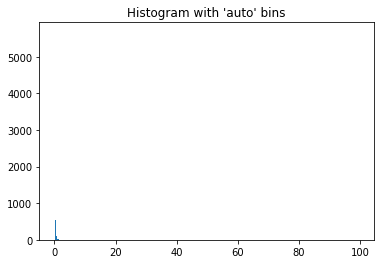

```python
####Visualizing Histogram that shows the outliers on a scale of one
import matplotlib.pyplot as plt
plt.hist(y_test_scores, bins='auto')  # arguments are passed to np.histogram
plt.title("Histogram with 'auto' bins")
plt.show()
```

###### Analyzing the visualization

The chart shows that there is a very minimal amount of outliers within this dataset. This is not necessarily a bad thing since the data has been normalized.

```python
###Identify the outliers as cluster and demonstrate the X attributes
df_test = pd.DataFrame(model)
df_test['score'] = y_test_scores
df_test['cluster'] = np.where(df_test['score']<1, 0, 1)
df_test['cluster'].value_counts()
```

```
0    160617
1      3420
Name: cluster, dtype: int64
```

```python
##Describe the outliers
#We recommend observations in Cluster 1 to be outliers.
#The attributes of Cluster 1 are shown below.
df_test.groupby('cluster').mean()
```

| cluster | 0 | 1 | 2 | 3 | 4 | 5 | 6 | 7 | 8 | 9 | ... | 24 | 25 | 26 | 27 | 28 | 29 | 30 | 31 | 32 | score |
| --- | --- | --- | --- | --- | --- | --- | --- | --- | --- | --- | --- | --- | --- | --- | --- | --- | --- | --- | --- | --- | --- |
| 0 | -0.022541 | -0.0303 | -0.029430 | -0.029865 | -0.030288 | -0.030715 | -0.031126 | -0.022541 | -0.059013 | -0.057659 | ... | -0.057671 | -0.057878 | -0.058080 | -0.058279 | -0.030312 | -0.058934 | -0.063933 | -0.057861 | -0.008711 | 0.191969 |
| 1 | 1.058602 | 1.4230 | 1.382142 | 1.402593 | 1.422424 | 1.442490 | 1.461788 | 1.058602 | 2.771511 | 2.707908 | ... | 2.708443 | 2.718187 | 2.727661 | 2.737012 | 1.423563 | 2.767782 | 3.002549 | 2.717399 | 0.409117 | 1.821165 |

2 rows × 34 columns

## Aggregating multiple models

We will take the features identified in the above examples and apply different calculations for the purpose of identifying outliers. Specifically, we will look at the below approaches to identify them:

1. Average: average scores of all detectors.
2. Maximum of Maximum (MOM)
3. Average of Maximum (AOM)
4. Maximum of Average (MOA)

```python
##Achieve Model Stability by Aggregating Multiple Models
n_clf = 30
k_list = [10, 20, 30, 40, 50, 60, 70, 80, 90, 100, 110,
          120, 130, 140, 150, 160, 170, 180, 190, 200]

train_scores = np.zeros([model.shape[0], n_clf])
test_scores = np.zeros([model.shape[0], n_clf])
```

```python
#for i in range(n_clf):
#        k = k_list[i]

#        clf = KNN(n_neighbors=k, method='largest')
#        clf.fit(model)

#        train_scores[:, i] = clf.decision_scores_
#        y_test_scores[:, i] = clf.decision_function(model) # Predict raw anomaly score of X using
                                                               #the fitted detector

#Above function of aggreagation could not be compiled due to 'IndexError: too many indices for array' error
```

[output not shown]

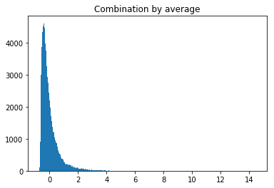

```python
## Combination by average
y_by_average = average(model)

import matplotlib.pyplot as plt
plt.hist(y_by_average, bins='auto')  # arguments are passed to np.histogram
plt.title("Combination by average")
plt.show()
```

```python
df_test = pd.DataFrame(model)
df_test['y_by_average_score'] = y_by_average
df_test['y_by_average_cluster'] = np.where(df_test['y_by_average_score']<0, 0, 1)
df_test['y_by_average_cluster'].value_counts()

df_test.groupby('y_by_average_cluster').mean()
```

| y_by_average_cluster | 0 | 1 | 2 | 3 | 4 | 5 | 6 | 7 | 8 | 9 | ... | 24 | 25 | 26 | 27 | 28 | 29 | 30 | 31 | 32 | y_by_average_score |
| --- | --- | --- | --- | --- | --- | --- | --- | --- | --- | --- | --- | --- | --- | --- | --- | --- | --- | --- | --- | --- | --- |
| 0 | -0.101469 | -0.205415 | -0.202903 | -0.204184 | -0.205374 | -0.206537 | -0.207594 | -0.101469 | -0.412402 | -0.410572 | ... | -0.442356 | -0.442662 | -0.442898 | -0.443116 | -0.205247 | -0.412053 | -0.446250 | -0.442591 | -0.037469 | -0.332981 |
| 1 | 0.194299 | 0.393342 | 0.388533 | 0.390984 | 0.393264 | 0.395491 | 0.397516 | 0.194299 | 0.789695 | 0.786191 | ... | 0.847053 | 0.847639 | 0.848091 | 0.848508 | 0.393020 | 0.789027 | 0.854508 | 0.847502 | 0.071748 | 0.637614 |

2 rows × 34 columns

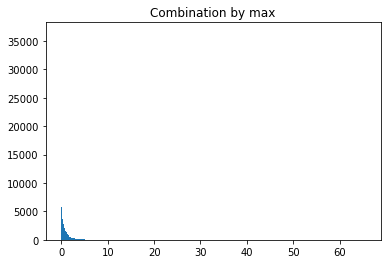

```python
###Maximum of maximum
# Combination by max
y_by_maximization = maximization(model)

import matplotlib.pyplot as plt
plt.hist(y_by_maximization, bins='auto')  # arguments are passed to np.histogram
plt.title("Combination by max")
plt.show()
```

```python
df_test = pd.DataFrame(model)
df_test['y_by_maximization_score'] = y_by_maximization
df_test['y_by_maximization_cluster'] = np.where(df_test['y_by_maximization_score']<0, 0, 1)
df_test['y_by_maximization_cluster'].value_counts()
```

```
1    115902
0     48135
Name: y_by_maximization_cluster, dtype: int64
```

```python
#Desrcibe the outliers
df_test.groupby('y_by_maximization_cluster').mean()
```

| y_by_maximization_cluster | 0 | 1 | 2 | 3 | 4 | 5 | 6 | 7 | 8 | 9 | ... | 24 | 25 | 26 | 27 | 28 | 29 | 30 | 31 | 32 | y_by_maximization_score |
| --- | --- | --- | --- | --- | --- | --- | --- | --- | --- | --- | --- | --- | --- | --- | --- | --- | --- | --- | --- | --- | --- |
| 0 | -0.101469 | -0.412707 | -0.410294 | -0.411568 | -0.412663 | -0.413648 | -0.414424 | -0.101469 | -0.520307 | -0.518788 | ... | -0.500568 | -0.500851 | -0.501061 | -0.501251 | -0.412369 | -0.519867 | -0.528648 | -0.500775 | -0.152444 | -0.081635 |
| 1 | 0.042141 | 0.171401 | 0.170398 | 0.170927 | 0.171382 | 0.171791 | 0.172114 | 0.042141 | 0.216087 | 0.215457 | ... | 0.207890 | 0.208007 | 0.208095 | 0.208173 | 0.171260 | 0.215905 | 0.219552 | 0.207976 | 0.063311 | 1.204794 |

2 rows × 34 columns

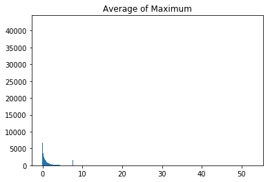

```python
##Average of Maximum
# Combination by aom
y_by_aom = aom(model, n_buckets=5, method = 'dynamic')

import matplotlib.pyplot as plt
plt.hist(y_by_aom, bins='auto')  # arguments are passed to np.histogram
plt.title("Average of Maximum")
plt.show()
```

```python
df_test = pd.DataFrame(model)
df_test['y_by_aom_score'] = y_by_aom
df_test['y_by_aom_cluster'] = np.where(df_test['y_by_aom_score']<0, 0, 1)
df_test['y_by_aom_cluster'].value_counts()
```

```
1    107750
0     56287
Name: y_by_aom_cluster, dtype: int64
```

```python
##Describe the outlier
df_test.groupby('y_by_aom_cluster').mean()
```

| y_by_aom_cluster | 0 | 1 | 2 | 3 | 4 | 5 | 6 | 7 | 8 | 9 | ... | 24 | 25 | 26 | 27 | 28 | 29 | 30 | 31 | 32 | y_by_aom_score |
| --- | --- | --- | --- | --- | --- | --- | --- | --- | --- | --- | --- | --- | --- | --- | --- | --- | --- | --- | --- | --- | --- |
| 0 | -0.101469 | -0.403734 | -0.401317 | -0.402591 | -0.403690 | -0.404683 | -0.405471 | -0.101469 | -0.519986 | -0.518466 | ... | -0.510613 | -0.510893 | -0.511098 | -0.511282 | -0.403403 | -0.519546 | -0.531522 | -0.510815 | -0.123803 | -0.081372 |
| 1 | 0.053006 | 0.210905 | 0.209642 | 0.210308 | 0.210882 | 0.211400 | 0.211812 | 0.053006 | 0.271633 | 0.270839 | ... | 0.266737 | 0.266883 | 0.266990 | 0.267086 | 0.210732 | 0.271403 | 0.277659 | 0.266842 | 0.064673 | 1.148166 |

2 rows × 34 columns

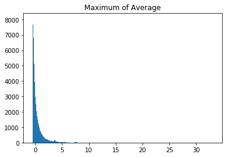

```python
##Maximum of Average
# Combination by moa
y_by_moa = moa(model, n_buckets=5, method = 'dynamic')

import matplotlib.pyplot as plt
plt.hist(y_by_moa, bins='auto')  # arguments are passed to np.histogram
plt.title("Maximum of Average")
plt.show()
```

```python
df_test = pd.DataFrame(model)
df_test['y_by_moa_score'] = y_by_moa
df_test['y_by_moa_cluster'] = np.where(df_test['y_by_moa_score']<0, 0, 1)
df_test['y_by_moa_cluster'].value_counts()
```

```
0    83973
1    80064
Name: y_by_moa_cluster, dtype: int64
```

```python
##Describe the outlier
df_test.groupby('y_by_moa_cluster').mean()
```

| y_by_moa_cluster | 0 | 1 | 2 | 3 | 4 | 5 | 6 | 7 | 8 | 9 | ... | 24 | 25 | 26 | 27 | 28 | 29 | 30 | 31 | 32 | y_by_moa_score |
| --- | --- | --- | --- | --- | --- | --- | --- | --- | --- | --- | --- | --- | --- | --- | --- | --- | --- | --- | --- | --- | --- |
| 0 | -0.101469 | -0.306752 | -0.304288 | -0.305566 | -0.306709 | -0.307786 | -0.308705 | -0.101469 | -0.502920 | -0.501350 | ... | -0.478840 | -0.479131 | -0.479351 | -0.479551 | -0.306501 | -0.502494 | -0.482640 | -0.479057 | -0.044358 | -0.255509 |
| 1 | 0.106423 | 0.321729 | 0.319145 | 0.320484 | 0.321684 | 0.322813 | 0.323777 | 0.106423 | 0.527474 | 0.525828 | ... | 0.502218 | 0.502524 | 0.502755 | 0.502964 | 0.321465 | 0.527028 | 0.506205 | 0.502446 | 0.046524 | 1.039405 |

2 rows × 34 columns

### Summary

While it was challenging to apply the PyOD package onto the dataset, it was hard to interpret the outliers and tie them back to a specific data point that could be used to identify the healthcare instance which could signal that there was a bad outlier involved.

## Meanshift Model

The meanshift model measures the shortest distances between points using eucledian distance to identify nearest pints. As opposed to other auto clustering methods (such as DBScan, for example), meanshift moves along the dense data point areas of the dataset in order to identify which items belong to a cluster. It is considered a 'hill climbing' algorithim since it begins to calculate the clusters starting at a random point and then calculating which are the nearest features within the dataset. Since it looks for datapoints which are near each other, the model naturally moves towards the denser regions of where the data lies in the matrix. Once density within a window of points decreases, the model completes that cluster and moves to repeat this process on other, non covered data points in the set.

```python
#####Applying the meanshift algoirthim to the feature set
from sklearn.cluster import MeanShift, estimate_bandwidth
from sklearn.datasets.samples_generator import make_blobs

# The following bandwidth can be automatically detected using
bandwidth = estimate_bandwidth(model, quantile=0.25, n_samples=5000)

ms = MeanShift(bandwidth=bandwidth, bin_seeding=True)
ms.fit(model)
labels = ms.labels_
cluster_centers = ms.cluster_centers_

labels_unique = np.unique(labels)
n_clusters_ = len(labels_unique)

print("number of estimated clusters : %d" % n_clusters_)
```

```
number of estimated clusters : 28
```

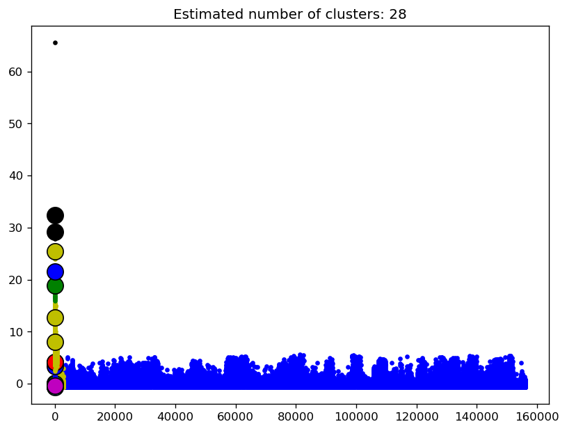

```python
##Plotting Meanshift Results
import matplotlib.pyplot as plt
from itertools import cycle

plt.figure(num=None, figsize=(8, 6), dpi=120, facecolor='w', edgecolor='k')
plt.clf()

colors = cycle('bgrcmykbgrcmykbgrcmykbgrcmykbgrcmykbgrcmykbgrcmykbgrcmykbgrcmykbgrcmykbgrcmykbgrcmyk')
for k, col in zip(range(n_clusters_), colors):
    my_members = labels == k
    cluster_center = cluster_centers[k]
    plt.plot(
             model[my_members, 1],
             col + '.')
    plt.plot( cluster_center[1], 'o', markerfacecolor=col,
             markeredgecolor='k', markersize=14)
plt.title('Estimated number of clusters: %d' % n_clusters_)
plt.show()
```

```python
ms.labels_
```

```
array([0, 0, 0, ..., 0, 0, 0], dtype=int64)
```

### Summary

The Meanshift clustering was succesufl in creating 28 clusters out of the data, however in the way that it was visualized it was not very interpretable. There were a few outliers found which were not able to be clustered into larger groupings. With more work and modification of model setup, meanshift could serve very useful in computing a good outlier predictor.

## Conclusion

In this document we were able to apply the principles of analyzing the healtcare dataset that was applied in R and used Python approachs to determine. We were able to make similar groupings of features and then apply KNN model by applying averages of particular outliers identified.

Going forward, I would like to get a better understanding of interpreting results from Python and being able to go backwards in identifying specific instances where outliers could be identified in the initial dataset.